# individual1

Kellan Bouwman

9/8/2020

## Lab 2

1. How are the ratings distributed? Create both a histogram and a boxplot and describe them. Don’t forget to mention outliers, if there are any.

   Answer: The graph is fairly left skewed, but most of the data is centralized from 2.5 - 3.5 with nothing existing right after 3.00.

```r
choco <- read.csv("https://raw.githubusercontent.com/xdaiISU/ds202materials/master/hwlabs/data/choco.csv")
str(choco)
```

```
## 'data.frame':    2312 obs. of  13 variables:
##  $ REF                 : int  2454 2458 2454 797 797 1015 1019 1011 1019 1011 ...
##  $ Company             : chr  "5150" "5150" "5150" "A. Morin" ...
##  $ Location            : chr  "U.S.A." "U.S.A." "U.S.A." "France" ...
##  $ Date                : int  2019 2019 2019 2012 2012 2013 2013 2013 2013 2013 ...
##  $ Bean_Origin         : chr  "Madagascar" "Dominican Republic" "Tanzania" "Peru" ...
##  $ Specific_Bean_Origin: chr  "Bejofo Estate, batch 1" "Zorzal, batch 1" "Kokoa Kamili, batch 1" "Peru" ...
##  $ Cocoa_Percent       : num  76 76 76 63 70 70 63 70 70 70 ...
##  $ Ingredients         : chr  "3- B,S,C" "3- B,S,C" "3- B,S,C" "4- B,S,C,L" ...
##  $ Characteristics1    : chr  "cocoa" "cocoa" "rich cocoa" "fruity" ...
##  $ Characteristics2    : chr  "blackberry" "vegetal" "fatty" "melon" ...
##  $ Characteristics3    : chr  "full body" "savory" "bready" "roasty" ...
##  $ Characteristics4    : chr  NA NA NA NA ...
##  $ Rating              : num  3.75 3.5 3.25 3.75 3.5 4 4 3.75 3.5 3.25 ...
```

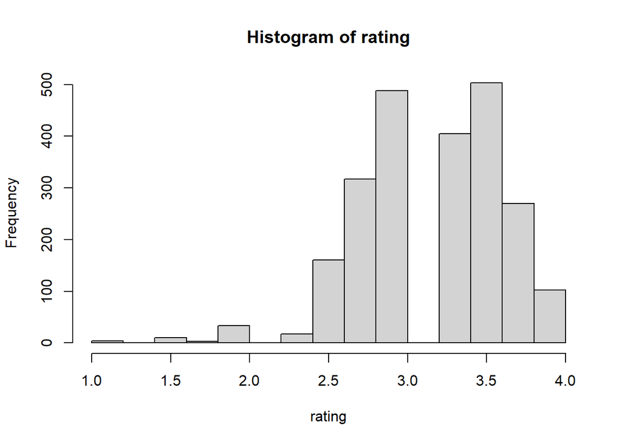

```r
rating = choco$Rating
hist(rating)
```

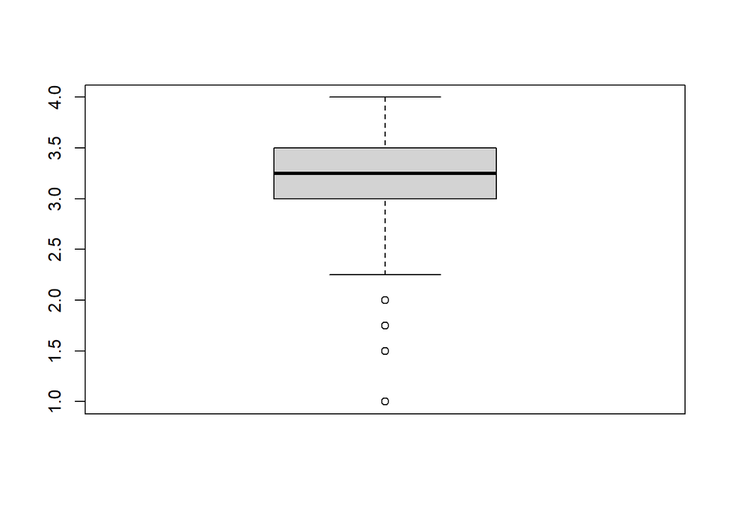

```r
boxplot(rating)
```

2. How does the number of ratings depend on the year? Draw a bar chart of the number of reports.

   Answer: There is little effect on what year it is by what the ratings are. There is a large amount of osolation in raitngs though over time.

[figure not shown]

```r
barplot(choco$Rating,choco$Date)
```

3. Do ratings depend on the cacao percentage of a chocolate bar? Create both numerical and graphical summaries, and explain.

   Answer:No there is no direct eveidence when looking at all of the data to say that the ratings and cocoa percent are corralated linearly. There is no visable trend, however most of the data is clustered togehter from approximatly 55% Cocoa to 90% and from a rating 2.0 to 3.5. This cluster suggests both that there is an active lurking data, and due to the non-continous vairble of rating that data points are most likely over lapping.

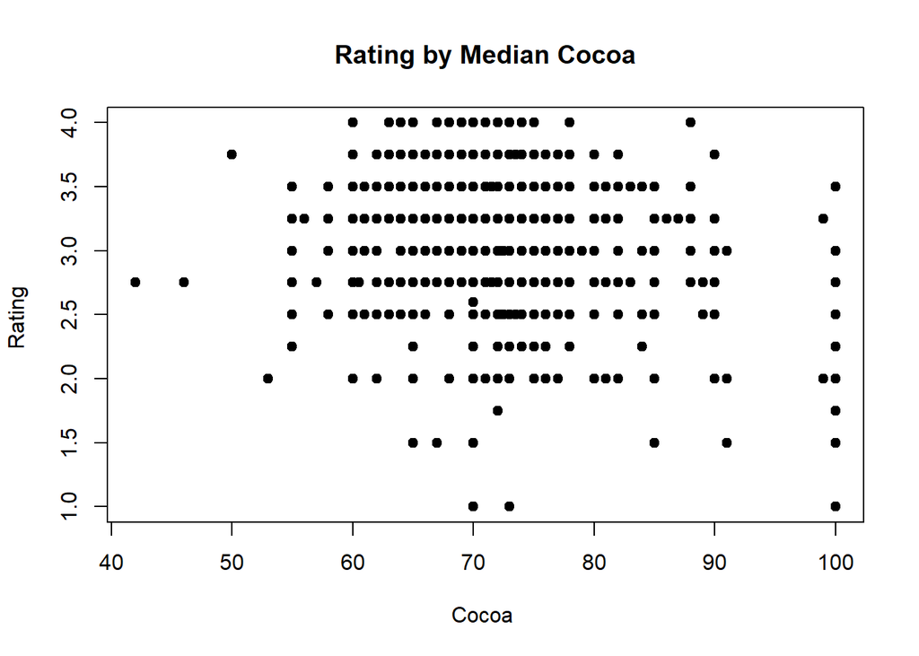

```r
plot(choco$Cocoa_Percent,choco$Rating, main="Rating by Median Cocoa", xlab="Cocoa ", ylab="Rating ", pch=19)
```

```r
cor(choco$Cocoa_Percent,choco$Rating)
```

```
## [1] -0.1510178
```

4. How do different characteristics of the chocolate compare? To elaborate, which characteristics tend to be more favorable and which ones are not? Create both numerical and graphical summaries, and explain.

   Answer: in characteristics1 the characteristic dirt had the highest value, for characteristic2 it was rainins, for characteristic3 it was tang. This is not looking at which bars had all three characteristics at the same time, instaead looking the values in each one with its rating was, not the combined flavor.

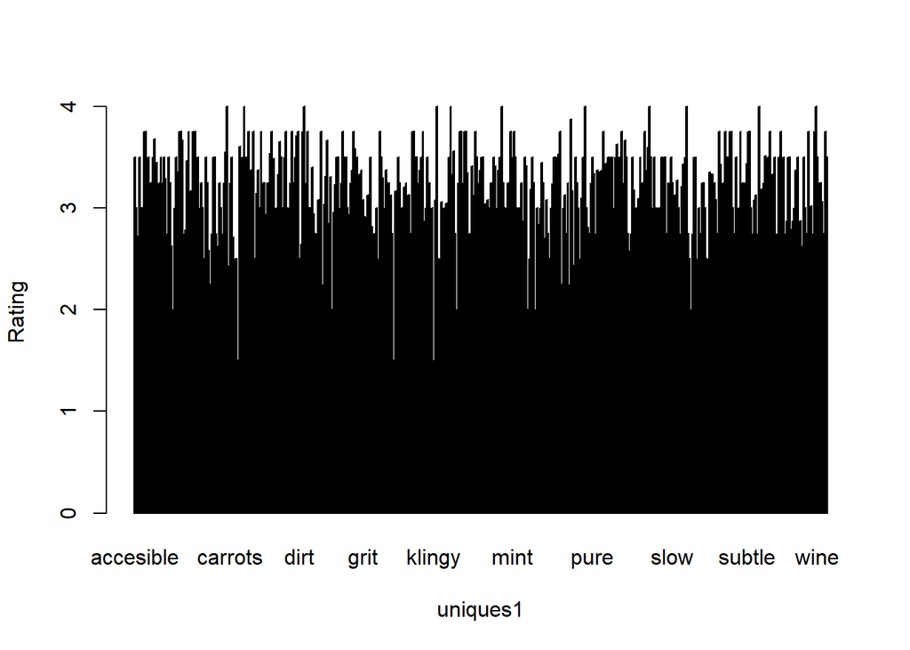

```r
characters1 <- c()
characters2 <- c()
characters3 <- c()
counter <- 0
for( row in 1:nrow(choco))
{
  characters1 <- c(characters1, choco[row, 'Characteristics1'])
  characters2 <- c(characters2, choco[row, 'Characteristics2'])
  characters3 <- c(characters3, choco[row, 'Characteristics3'])
  counter <- counter + 1
}
uniques1 <- unique(unlist(characters1, use.names = FALSE))
uniques2 <- unique(unlist(characters2, use.names = FALSE))
uniques3 <- unique(unlist(characters3, use.names = FALSE))
Rating <- c()
for( uniq in uniques1)
{
  curr <- choco[choco$Characteristics1 == uniq,]
  Rating <- c(Rating, mean(curr$Rating, na.rm = TRUE))
}
barplot(Rating ~ uniques1)
```

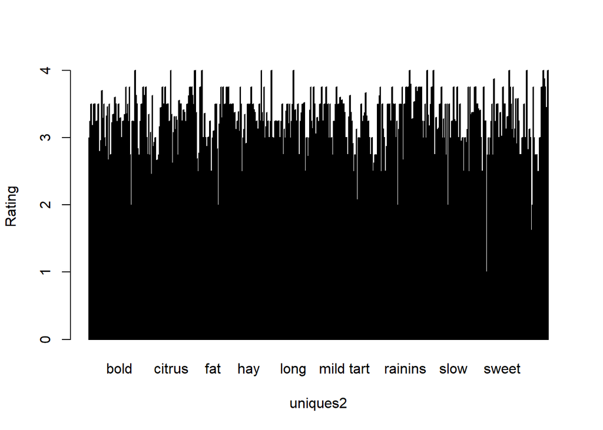

```r
Rating <- c()
for( uniq in uniques2)
{
  curr <- choco[choco$Characteristics2 == uniq,]
  Rating <- c(Rating, mean(curr$Rating, na.rm = TRUE))
}
barplot(Rating ~ uniques2)
```

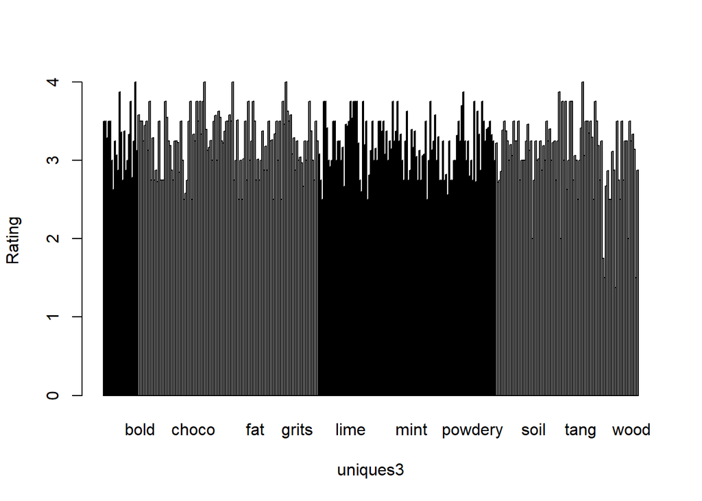

```r
Rating <- c()
for( uniq in uniques3)
{
  curr <- choco[choco$Characteristics3 == uniq,]
  Rating <- c(Rating, mean(curr$Rating, na.rm = TRUE))
}
barplot(Rating ~ uniques3)
```

5. Brainstorm two analyses you would like to perform with your teammate. Describe in plain language what comparisons are you making. Create suitable numerical and graphical summaries for your analyses. Describe the results.

```r
companies <- c()
Years <- c()
for( row in 1:nrow(choco))
{
  companies <- c(companies, choco[row, 'Company'])
  Years <-  c(companies, choco[row, 'Date'])
}
unique_companies <- unique(unlist(companies, use.names = FALSE))
unique_Years <-  unique(unlist(Years, use.names = FALSE))
meanRating <- c()
meanCocoa <- c()
for( uniq in unique_companies)
{
  curr <- choco[choco$Company == uniq,]
  meanRating <- c(meanRating, mean(curr$Rating, na.rm = TRUE))
  meanCocoa <- c(meanCocoa, mean(curr$Cocoa_Percent, na.rm = TRUE))
}
companyStats <- data.frame("Company" = unique_companies, "MeanRating" = meanRating, "MeanCocoa" = meanCocoa )
companyStats
```

```
##                                     Company MeanRating MeanCocoa
## 1                                      5150   3.500000  76.00000
## 2                                  A. Morin   3.400000  68.88000
## 3                                    Acalli   3.562500  71.00000
## 4             Adi aka Fijiana (Easy In Ltd)   3.250000  75.00000
## 5                                     Aelan   2.750000  70.00000
## 6                        Aequare (Gianduja)   2.875000  62.50000
## 7                                  Ah Cacao   3.000000  70.00000
## 8                        Akesson's (Pralus)   3.083333  75.00000
## 9                             Alain Ducasse   2.833333  73.33333
## 10                                Alexandre   3.500000  70.00000
## 11                    Altus aka Cao Artisan   2.863636  62.72727
## 12                                    Amano   3.416667  70.00000
## 13                    Amatller (Simon Coll)   2.875000  77.50000
## 14                            Amazing Cacao   3.250000  70.00000
```

[output cut: 527 more lines]

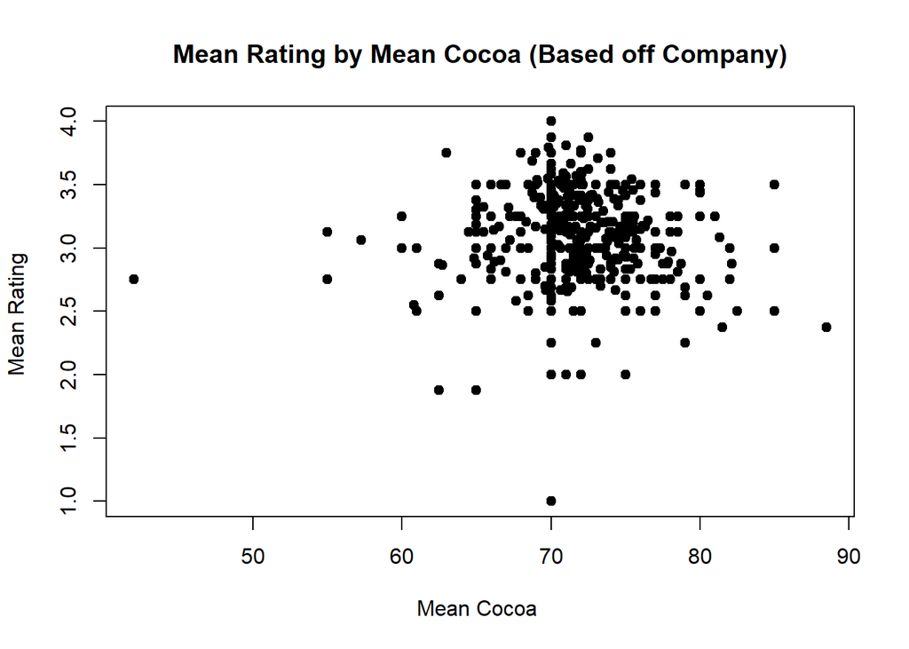

```r
plot(meanCocoa, meanRating, main="Mean Rating by Mean Cocoa (Based off Company)", xlab="Mean Cocoa ", ylab="Mean Rating ", pch=19)
```

[figure not shown]

```r
meanRatings <- c()
meanCocoas <- c()
for( uniques in unique_Years)
{
  curr <- choco[choco$Date == uniques,]
  meanRatings <- c(meanRatings, mean(curr$Rating, na.rm = TRUE))
  meanCocoas <- c(meanCocoas, mean(curr$Cocoa_Percent, na.rm = TRUE))
}
plot(meanCocoa, meanRating, main="Mean Rating by Mean Cocoa (Based off year)", xlab="Mean Cocoa ", ylab="Mean Rating ", pch=19)
```